# 2020 excess mortality & voting patterns in CH

Mortality data preparation (*Wohnort* based)

# Source

Custom file delivered by BfS covering 2021 period and standardizing municipalities to Jul 2021.

Using **Wohnort** (*the municipality where the person lived*) as unit of analysis.

```r
w_deaths_2015_2021 <- read_csv("data-raw/BfS-closed/monthly_deaths/13OCT21_Lieferung_Panczak_Wohnort.zip",
                               col_types = cols(year = col_integer(),
                                                month = col_integer(),
                                                COUNT = col_integer()),
                               locale = readr::locale(encoding = "latin1")) %>%
  mutate(sex = if_else(sex == "F", "Female", "Male")) %>%
  select(-canton, -community, -nationality) %>%
  rename(GMDNAME = wohnort,
         canton = wohnkanton) %>%
  # hyphen in name >> doesnt link to spatial data
  mutate(GMDNAME = if_else(GMDNAME == "La Grande-Béroche", "La Grande Béroche", GMDNAME)) %>%
  # name change? >> resolved with Cordula
  mutate(GMDNAME = if_else(GMDNAME == "Klosters-Serneus", "Klosters", GMDNAME))
```

# Municipality updates

To reach the state of `2022-01-01`.

```r
w_deaths_2015_2021 %<>%
  # Essertes merge
  mutate(GMDNAME = if_else(GMDNAME == "Essertes", "Oron", GMDNAME)) %>%
  # Zurzach
  mutate(GMDNAME = if_else(GMDNAME == "Bad Zurzach", "Zurzach", GMDNAME)) %>%
  mutate(GMDNAME = if_else(GMDNAME == "Baldingen", "Zurzach", GMDNAME)) %>%
  mutate(GMDNAME = if_else(GMDNAME == "Böbikon", "Zurzach", GMDNAME)) %>%
  mutate(GMDNAME = if_else(GMDNAME == "Kaiserstuhl", "Zurzach", GMDNAME)) %>%
  mutate(GMDNAME = if_else(GMDNAME == "Rekingen (AG)", "Zurzach", GMDNAME)) %>%
  mutate(GMDNAME = if_else(GMDNAME == "Rietheim", "Zurzach", GMDNAME)) %>%
  mutate(GMDNAME = if_else(GMDNAME == "Rümikon", "Zurzach", GMDNAME)) %>%
  mutate(GMDNAME = if_else(GMDNAME == "Wislikofen", "Zurzach", GMDNAME)) %>%
  # Böztal merge
  mutate(GMDNAME = if_else(GMDNAME == "Bözen", "Böztal", GMDNAME)) %>%
  mutate(GMDNAME = if_else(GMDNAME == "Effingen", "Böztal", GMDNAME)) %>%
  mutate(GMDNAME = if_else(GMDNAME == "Elfingen", "Böztal", GMDNAME)) %>%
  mutate(GMDNAME = if_else(GMDNAME == "Hornussen", "Böztal", GMDNAME)) %>%
  # Blonay - Saint-Légier merge
  mutate(GMDNAME = if_else(GMDNAME == "Blonay", "Blonay - Saint-Légier", GMDNAME)) %>%
  mutate(GMDNAME = if_else(GMDNAME == "Saint-Légier-La Chiésaz", "Blonay - Saint-Légier", GMDNAME)) %>%
  # Murten merge
  mutate(GMDNAME = if_else(GMDNAME == "Galmiz", "Murten", GMDNAME)) %>%
  mutate(GMDNAME = if_else(GMDNAME == "Gempenach", "Murten", GMDNAME)) %>%
  mutate(GMDNAME = if_else(GMDNAME == "Clavaleyres", "Murten", GMDNAME)) %>%
  # Schwende-Rüte merge
  mutate(GMDNAME = if_else(GMDNAME == "Schwende", "Schwende-Rüte", GMDNAME)) %>%
  mutate(GMDNAME = if_else(GMDNAME == "Rüte", "Schwende-Rüte", GMDNAME)) %>%
  # Val Mara merge
  mutate(GMDNAME = if_else(GMDNAME == "Melano", "Val Mara", GMDNAME)) %>%
  mutate(GMDNAME = if_else(GMDNAME == "Maroggia", "Val Mara", GMDNAME)) %>%
  mutate(GMDNAME = if_else(GMDNAME == "Rovio", "Val Mara", GMDNAME))
```

# Monthly aggregation

```r
w_deaths_2015_2021 %<>%
  group_by(year, month, canton, GMDNAME, agegroup, sex) %>%
  summarise(deaths = sum(COUNT)) %>%
  ungroup()
```

## Description of data

```
The data contains 267397 observations of the following 7 variables:

  - year: n = 267397, Mean = 2017.81, SD = 1.89, Median = 2018.00, MAD = 2.97,
range: [2015, 2021], Skewness = 0.03, Kurtosis = -1.19, 0% missing
  - month: n = 267397, Mean = 6.23, SD = 3.53, Median = 6.00, MAD = 4.45, range:
[1, 12], Skewness = 0.12, Kurtosis = -1.25, 0% missing
  - canton: 26 entries, such as BE (14.36%); ZH (12.24%); AG (9.35%) and 23
others (0 missing)
  - GMDNAME: 2143 entries, such as Zürich (0.46%); Genève (0.39%); Basel (0.38%)
and 2140 others (0 missing)
  - agegroup: 10 entries, such as [80-90) (31.11%); [90-116) (22.49%); [70-80)
(21.04%) and 7 others (0 missing)
  - sex: 2 entries, such as Male (51.58%); Female (48.42%); NA (0 missing)
  - deaths: n = 267397, Mean = 1.66, SD = 2.58, Median = 1.00, MAD = 0.00, range:
[1, 124], Skewness = 13.10, Kurtosis = 266.87, 0% missing
```

Data summary

| Name | w_deaths_2015_2021 |
| --- | --- |
| Number of rows | 267397 |
| Number of columns | 7 |
| _______________________ |  |
| Column type frequency: |  |
| character | 4 |
| numeric | 3 |
| ________________________ |  |
| Group variables | None |

**Variable type: character**

| skim_variable | n_missing | complete_rate | min | max | empty | n_unique | whitespace |
| --- | --- | --- | --- | --- | --- | --- | --- |
| canton | 0 | 1 | 2 | 2 | 0 | 26 | 0 |
| GMDNAME | 0 | 1 | 2 | 27 | 0 | 2143 | 0 |
| agegroup | 0 | 1 | 6 | 8 | 0 | 10 | 0 |
| sex | 0 | 1 | 4 | 6 | 0 | 2 | 0 |

**Variable type: numeric**

| skim_variable | n_missing | complete_rate | mean | sd | p0 | p25 | p50 | p75 | p100 | hist |
| --- | --- | --- | --- | --- | --- | --- | --- | --- | --- | --- |
| year | 0 | 1 | 2017.81 | 1.89 | 2015 | 2016 | 2018 | 2019 | 2021 | ▇▅▅▅▆ |
| month | 0 | 1 | 6.23 | 3.53 | 1 | 3 | 6 | 9 | 12 | ▇▅▅▅▇ |
| deaths | 0 | 1 | 1.66 | 2.58 | 1 | 1 | 1 | 2 | 124 | ▇▁▁▁▁ |

445,199 deaths by year:

```
# A tibble: 7 × 2
   year Deaths
  <int> <chr>
1  2015 67,617
2  2016 64,948
3  2017 66,982
4  2018 67,096
5  2019 67,793
6  2020 76,181
7  2021 34,582
```

# Codes of geographical areas

There were 2,145 municipalities on the `2022-01-01` in CH (mark #28 tho!).

2 had no deaths recorded during the study period.

```
# A tibble: 2 × 2
  GMDNAME   KTNAME
  <chr>     <chr>
1 Geltwil   AG
2 Rossenges VD
```

# Age groups

Original age groups:

```
agegroup <character>
# total N=267397 valid N=267397 mean=8.25 sd=1.65

Value    |     N | Raw % | Valid % | Cum. %
-------------------------------------------
[0-10)   |  2295 |  0.86 |    0.86 |   0.86
[10-20)  |   824 |  0.31 |    0.31 |   1.17
[20-30)  |  2092 |  0.78 |    0.78 |   1.95
[30-40)  |  3096 |  1.16 |    1.16 |   3.11
[40-50)  |  7299 |  2.73 |    2.73 |   5.84
[50-60)  | 18711 |  7.00 |    7.00 |  12.83
[60-70)  | 33492 | 12.53 |   12.53 |  25.36
[70-80)  | 56264 | 21.04 |   21.04 |  46.40
[80-90)  | 83196 | 31.11 |   31.11 |  77.51
[90-116) | 60128 | 22.49 |   22.49 | 100.00
<NA>     |     0 |  0.00 |    <NA> |   <NA>
```

```r
w_deaths_2015_2021 %<>%
  mutate(
    age = case_when(
      agegroup == "[0-10)" ~   "<40",
      agegroup == "[10-20)" ~  "<40",
      agegroup == "[20-30)" ~  "<40",
      agegroup == "[30-40)" ~  "<40",

      agegroup == "[40-50)" ~  "40-49",
      agegroup == "[50-60)" ~  "50-59",
      agegroup == "[60-70)" ~  "60-69",
      agegroup == "[70-80)" ~  "70-79",

      agegroup == "[80-90)" ~  "80+",
      agegroup == "[90-116)" ~ "80+" ,
      TRUE ~                    agegroup)
  ) %>%
  select(-agegroup) %>%
  group_by(GMDNAME, year, month, canton, sex, age) %>%
  summarise(deaths = sum(deaths)) %>%
  ungroup()
```

```
age <character>
# total N=235870 valid N=235870 mean=4.95 sd=1.32

Value |      N | Raw % | Valid % | Cum. %
-----------------------------------------
<40   |   7736 |  3.28 |    3.28 |   3.28
40-49 |   7299 |  3.09 |    3.09 |   6.37
50-59 |  18711 |  7.93 |    7.93 |  14.31
60-69 |  33492 | 14.20 |   14.20 |  28.51
70-79 |  56264 | 23.85 |   23.85 |  52.36
80+   | 112368 | 47.64 |   47.64 | 100.00
<NA>  |      0 |  0.00 |    <NA> |   <NA>
```

# Distribution of death counts

Obviously highly skewed.  
**Note:** *No zeroes here yet! No pop denominator either!*

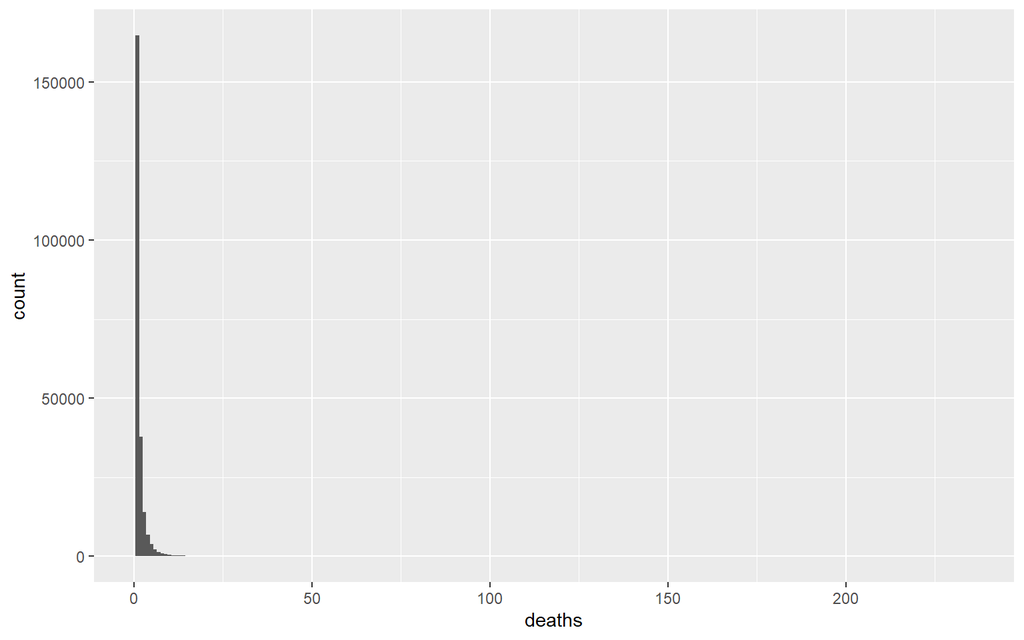

## Filling with zeroes

All possible combinations of `year, month, canton, municipality, age & sex` are used and then empty strata are filled with zeroes.

This expansion also includes municipalities with zero deaths described above.

```r
w_deaths_2015_2021_exp <-
  raum %>%
  select(GMDNAME) %>%
  distinct() %>%
  left_join(w_deaths_2015_2021) %>%
  select(-deaths, -canton) %>%
  # avoiding NAs in three communities without cases
  mutate(
    year = if_else(is.na(year), as.integer(2015), year),
    month = if_else(is.na(month), as.integer(1), month),
    sex = if_else(is.na(sex), "Male", sex),
    age = if_else(is.na(age), "<40", age)
  ) %>%
  expand(GMDNAME, year, month, sex, age) %>%
  left_join(w_deaths_2015_2021) %>%
  replace_na(list(deaths = 0)) %>%
  mutate(date = ymd(paste(year, month, "1", sep = " "))) %>%
  relocate(date, .after = month) %>%
  left_join(raum) %>%
  select(-canton) %>%
  relocate(GMDNR, .before = GMDNAME) %>%
  relocate(KTNR, id_kt, KTNAME, .after = GMDNAME) %>%
  arrange(GMDNR, year, month, age, sex) %>%
  filter( !(year == 2021 & month > 6))
```

## Zero cells

Needless to say that creates large amount of zero cells:

[figure not shown]

```
deaths == 0 <lgl>
# total N=2007720 valid N=2007720 mean=0.88 sd=0.32

Value |       N | Raw % | Valid % | Cum. %
------------------------------------------
FALSE |  235870 | 11.75 |   11.75 |  11.75
TRUE  | 1771850 | 88.25 |   88.25 | 100.00
<NA>  |       0 |  0.00 |    <NA> |   <NA>
```

Situation only marginally improves with exclusion of `<40` age group stratum:

```
deaths == 0 <lgl>
# total N=1673100 valid N=1673100 mean=0.86 sd=0.34

Value |       N | Raw % | Valid % | Cum. %
------------------------------------------
FALSE |  228134 | 13.64 |   13.64 |  13.64
TRUE  | 1444966 | 86.36 |   86.36 | 100.00
<NA>  |       0 |  0.00 |    <NA> |   <NA>
```

# Examples of time series

## Municipalities Bern & Meienried:

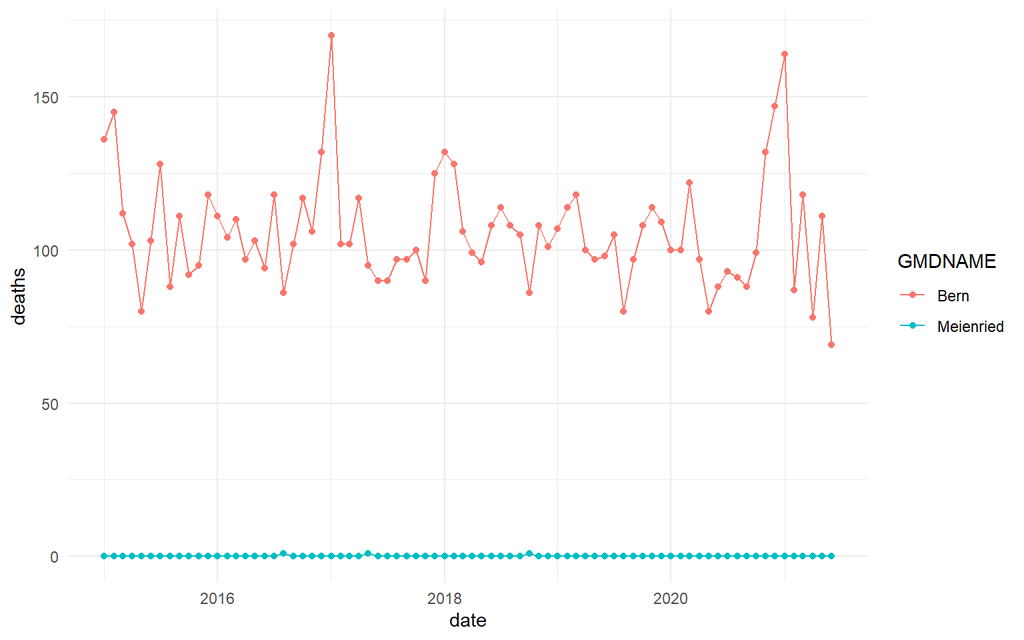

## All time series

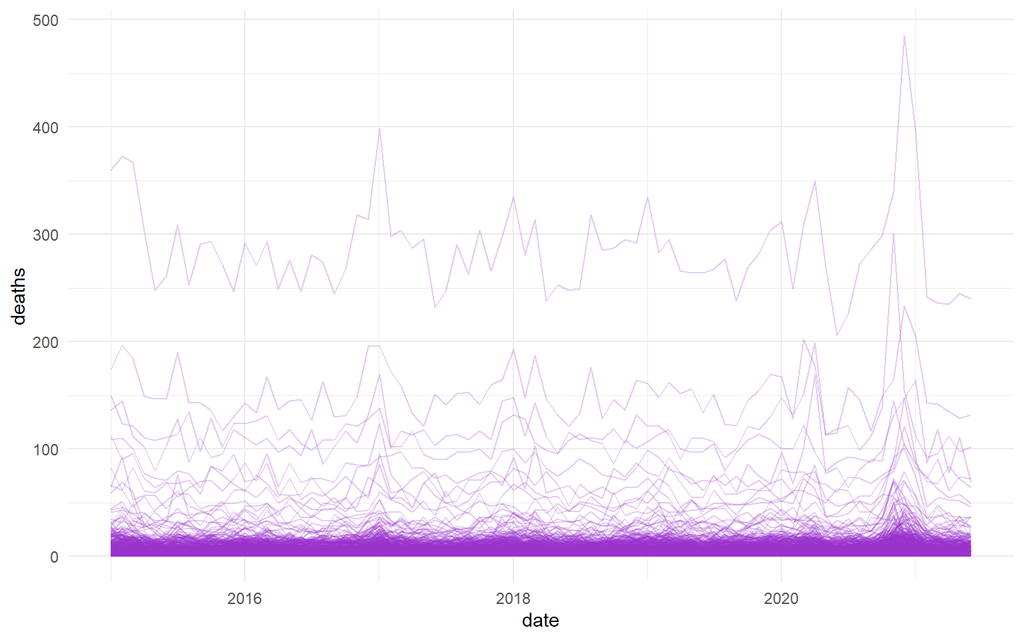

# Yearly aggregation

Excluding 2021.

```r
w_deaths_2015_2020_year <- w_deaths_2015_2021_exp %>%
  filter(year < 2021) %>%
  group_by(year, KTNAME, KTNR, id_kt, GMDNR, GMDNAME,
           ARGRNR, ARGRNAME,
           ARNR, ARNAME, border,
           sex, age) %>%
  summarise(deaths = sum(deaths)) %>%
  ungroup()
```

## Miscelaneous ID variables for INLA

```r
gg <- read_rds("data/BfS/gg.Rds") %>%
  sf::st_drop_geometry() %>%
  select(GMDNR, id_space)

w_deaths_2015_2020_year %<>%
  left_join(gg) %>%
  mutate(
    id_age = as.integer(as.factor(age)),
    observed = deaths,
    deaths = if_else(year == 2020, NA_integer_, deaths)) %>%
  relocate(observed, .after = deaths) %>%
  relocate(id_space, .after = GMDNR) %>%
  relocate(id_age, .after = age)
```

## Description of data

```
The data contains 154440 observations of the following 14 variables:

  - year: n = 154440, Mean = 2017.50, SD = 1.71, Median = 2017.50, MAD = 2.22,
range: [2015, 2020], Skewness = 0.00, Kurtosis = -1.27, 0% missing
  - KTNAME: 26 entries, such as BE (15.76%); VD (13.99%); AG (9.32%) and 23
others (0 missing)
  - KTNR: n = 154440, Mean = 13.61, SD = 8.49, Median = 17.00, MAD = 8.90, range:
[1, 26], Skewness = -0.32, Kurtosis = -1.46, 0% missing
  - GMDNR: n = 154440, Mean = 3289.82, SD = 2133.44, Median = 3296.00, MAD =
3224.65, range: [1, 6810], Skewness = -0.02, Kurtosis = -1.36, 0% missing
  - GMDNAME: 2145 entries, such as Aadorf (0.05%); Aarau (0.05%); Aarberg (0.05%)
and 2142 others (0 missing)
  - ARGRNR: 16 entries, such as 12 (14.17%); 02 (12.26%); 05 (8.58%) and 13
others (0 missing)
  - ARGRNAME: 16 entries, such as Region Zürich (14.17%); Region Lausanne
(12.26%); Region Biel–Jura (8.58%) and 13 others (0 missing)
  - ARNR: 101 entries, such as 10020 (4.38%); 12010 (3.64%); 02030 (3.03%) and 98
others (0 missing)
  - ARNAME: 101 entries, such as Aarau-Olten (4.38%); Baden (3.64%); Solothurn
(3.03%) and 98 others (0 missing)
  - border: n = 154440, Mean = 0.20, SD = 0.40, Median = 0.00, MAD = 0.00, range:
[0, 1], Skewness = 1.53, Kurtosis = 0.35, 0% missing
  - sex: 2 entries, such as Female (50.00%); Male (50.00%); NA (0 missing)
  - age: 6 entries, such as <40 (16.67%); 40-49 (16.67%); 50-59 (16.67%) and 3
others (0 missing)
  - deaths: n = 154440, Mean = 2.60, SD = 15.76, Median = , MAD = 0.00, range:
[0, 1492], Skewness = 45.25, Kurtosis = 3173.33, 16.67% missing
  - observed: n = 154440, Mean = 2.66, SD = 16.03, Median = 0.00, MAD = 0.00,
range: [0, 1493], Skewness = 44.55, Kurtosis = 3087.82, 0% missing
```

Data summary

| Name | w_deaths_2015_2020_year |
| --- | --- |
| Number of rows | 154440 |
| Number of columns | 17 |
| _______________________ |  |
| Column type frequency: |  |
| character | 8 |
| numeric | 9 |
| ________________________ |  |
| Group variables | None |

**Variable type: character**

| skim_variable | n_missing | complete_rate | min | max | empty | n_unique | whitespace |
| --- | --- | --- | --- | --- | --- | --- | --- |
| KTNAME | 0 | 1 | 2 | 2 | 0 | 26 | 0 |
| GMDNAME | 0 | 1 | 2 | 27 | 0 | 2145 | 0 |
| ARGRNR | 0 | 1 | 2 | 2 | 0 | 16 | 0 |
| ARGRNAME | 0 | 1 | 8 | 16 | 0 | 16 | 0 |
| ARNR | 0 | 1 | 5 | 5 | 0 | 101 | 0 |
| ARNAME | 0 | 1 | 3 | 30 | 0 | 101 | 0 |
| sex | 0 | 1 | 4 | 6 | 0 | 2 | 0 |
| age | 0 | 1 | 3 | 5 | 0 | 6 | 0 |

**Variable type: numeric**

| skim_variable | n_missing | complete_rate | mean | sd | p0 | p25 | p50 | p75 | p100 | hist |
| --- | --- | --- | --- | --- | --- | --- | --- | --- | --- | --- |
| year | 0 | 1.00 | 2017.50 | 1.71 | 2015 | 2016 | 2017.5 | 2019 | 2020 | ▇▃▃▃▃ |
| KTNR | 0 | 1.00 | 13.61 | 8.49 | 1 | 3 | 17.0 | 22 | 26 | ▇▃▂▇▇ |
| id_kt | 0 | 1.00 | 13.61 | 8.49 | 1 | 3 | 17.0 | 22 | 26 | ▇▃▂▇▇ |
| GMDNR | 0 | 1.00 | 3289.82 | 2133.44 | 1 | 1067 | 3296.0 | 5411 | 6810 | ▇▃▅▅▇ |
| id_space | 0 | 1.00 | 1073.00 | 619.21 | 1 | 537 | 1073.0 | 1609 | 2145 | ▇▇▇▇▇ |
| border | 0 | 1.00 | 0.20 | 0.40 | 0 | 0 | 0.0 | 0 | 1 | ▇▁▁▁▂ |
| id_age | 0 | 1.00 | 3.50 | 1.71 | 1 | 2 | 3.5 | 5 | 6 | ▇▃▃▃▃ |
| deaths | 25740 | 0.83 | 2.60 | 15.76 | 0 | 0 | 0.0 | 2 | 1492 | ▇▁▁▁▁ |
| observed | 0 | 1.00 | 2.66 | 16.03 | 0 | 0 | 0.0 | 2 | 1493 | ▇▁▁▁▁ |

## Zero cells

Less but still large amount of zero cells:

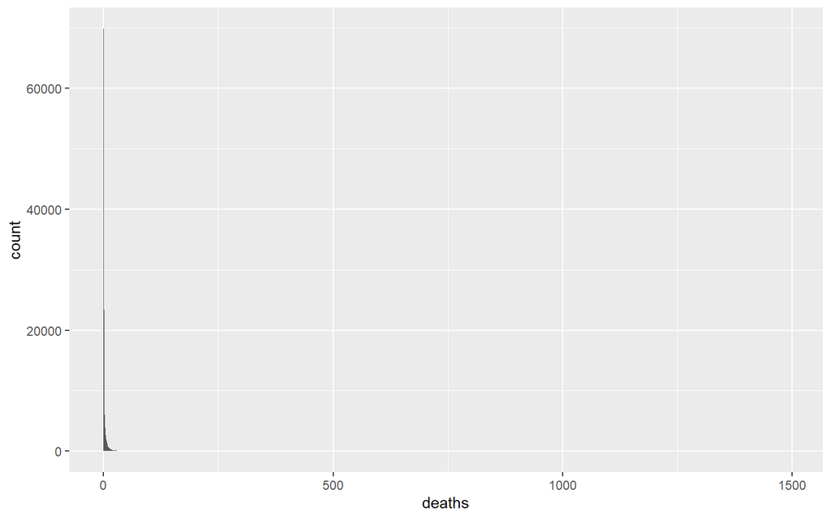

```
deaths == 0 <lgl>
# total N=154440 valid N=128700 mean=0.54 sd=0.50

Value |     N | Raw % | Valid % | Cum. %
----------------------------------------
FALSE | 58908 | 38.14 |   45.77 |  45.77
TRUE  | 69792 | 45.19 |   54.23 | 100.00
<NA>  | 25740 | 16.67 |    <NA> |   <NA>
```

Situation only marginally improves with exclusion of `<40` age group stratum:

```
deaths == 0 <lgl>
# total N=128700 valid N=107250 mean=0.49 sd=0.50

Value |     N | Raw % | Valid % | Cum. %
----------------------------------------
FALSE | 54894 | 42.65 |   51.18 |  51.18
TRUE  | 52356 | 40.68 |   48.82 | 100.00
<NA>  | 21450 | 16.67 |    <NA> |   <NA>
```

## Examples of Bern & Meienried:

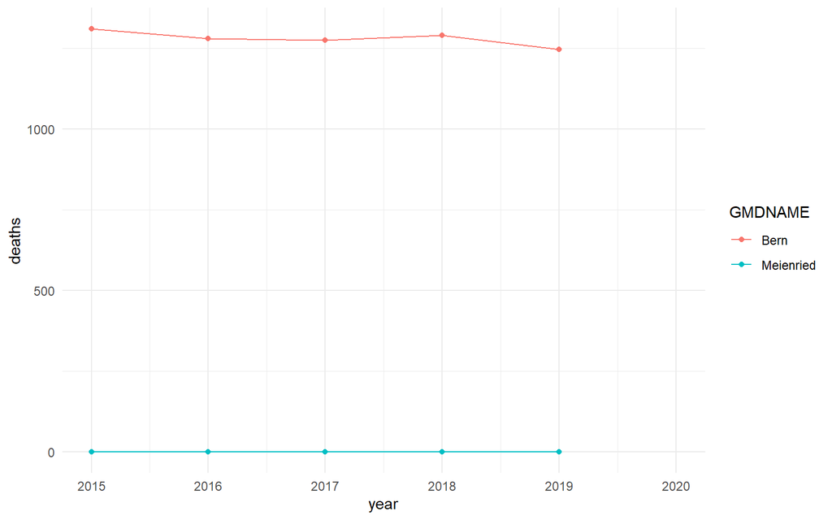